# Assignment 4

*NOTE: Worked with Janice Luong, Chad Pickering, Hannah Kosinovsky, Graham Smith, and Patrick Vacek. I StackOverflow was used as a source a lot.*

In this assignment, you'll combine the assignment 3 data set with nutrition data from the [USDA Food Composition Databases](https://ndb.nal.usda.gov/ndb/search/list). The CSV file `fresh.csv` contains the fresh fruits and vegetables data you extracted in assignment 3.

The USDA Food Composition Databases have a [documented](https://ndb.nal.usda.gov/ndb/doc/index) web API that returns data in JSON format . You need a key in order to use the API. Only 1000 requests are allowed per hour, so it would be a good idea to use [caching](https://pypi.python.org/pypi/requests-cache).

[Sign up for an API key here](https://api.data.gov/signup/). The key will work with any Data.gov API. You may need the key again later in the quarter, so make sure you save it.

These modules may be useful:

- [requests](http://docs.python-requests.org/en/master/user/quickstart/)
- [requests_cache](https://pypi.python.org/pypi/requests-cache)
- [urlparse](https://docs.python.org/2/library/urlparse.html)
- [pandas](http://pandas.pydata.org/pandas-docs/stable/)

**Exercise 1.1.** Read the [search request documentation](https://ndb.nal.usda.gov/ndb/doc/apilist/API-SEARCH.md), then write a function called `ndb_search()` that makes a search request. The function should accept the search term as an argument. The function should return the search result items as a list (for 0 items, return an empty list).

Note that the search url is: `https://api.nal.usda.gov/ndb/search`

As an example, a search for `"quail eggs"` should return this list:

```
[{u'ds': u'BL',
  u'group': u'Branded Food Products Database',
  u'name': u'CHAOKOH, QUAIL EGG IN BRINE, UPC: 044738074186',
  u'ndbno': u'45094707',
  u'offset': 0},
 {u'ds': u'BL',
  u'group': u'Branded Food Products Database',
  u'name': u'L&W, QUAIL EGGS, UPC: 024072000256',
  u'ndbno': u'45094890',
  u'offset': 1},
 {u'ds': u'BL',
  u'group': u'Branded Food Products Database',
  u'name': u'BUDDHA, QUAIL EGGS IN BRINE, UPC: 761934535098',
  u'ndbno': u'45099560',
  u'offset': 2},
 {u'ds': u'BL',
  u'group': u'Branded Food Products Database',
  u'name': u'GRAN SABANA, QUAIL EGGS, UPC: 819140010103',
  u'ndbno': u'45169279',
  u'offset': 3},
 {u'ds': u'BL',
  u'group': u'Branded Food Products Database',
  u'name': u"D'ARTAGNAN, QUAIL EGGS, UPC: 736622102630",
  u'ndbno': u'45178254',
  u'offset': 4},
 {u'ds': u'SR',
  u'group': u'Dairy and Egg Products',
  u'name': u'Egg, quail, whole, fresh, raw',
  u'ndbno': u'01140',
  u'offset': 5}]
```

As usual, make sure you document and test your function.

```python
import requests
import pandas as pd
import json
import numpy as np
import re
```

```python
from fastcache import clru_cache
@clru_cache(maxsize=128,typed=False)

def ndb_search(term):
    url = "https://api.nal.usda.gov/ndb/search"

    #list of parameters: q is term, format is json, sorted by relevance, api_key is my key, and ds is standard reference
    params = {"q" : term,
              "format" : "json",
              "sort" : "r",
              "api_key" : "S8zY8kgwqX4fHLwCC9NR1H67JFOKSce11RI5i16U",
              "ds": "Standard Reference"}

    #retrieve the data
    response = requests.get(url, params)

    #return response.json() # parse JSON
    json_object = response.json()

    # return elements of json_obj (as "list", "item") when they are present or return an empty list when there is a KeyError
    try:
        list_out = json_object["list"]["item"]
    except KeyError:
        list_out=[]
    return(list_out)

ndb_search("quail eggs")
```

```
[{u'ds': u'SR',
  u'group': u'Dairy and Egg Products',
  u'name': u'Egg, quail, whole, fresh, raw',
  u'ndbno': u'01140',
  u'offset': 0}]
```

```python
key = "S8zY8kgwqX4fHLwCC9NR1H67JFOKSce11RI5i16U"

from fastcache import clru_cache
@clru_cache(maxsize=128,typed=False)

# query on USDA db, output json object (list of items)
def ndb_search(term):
    # creating url with search term
    url = "https://api.nal.usda.gov/ndb/search/?format=json&q="+term

    # append remainder of url
    #includes key and specifies the data source so it only grabs standard reference, not branded food products
    search_url = url+"&sort=r&offset=0&api_key="+key+"&ds=Standard Reference"

    # use caching mechanism and retrieve the data
    request = requests.get(search_url)

    # make json object
    json_object = request.json()

    # return elements of json_obj (as "list", "item") when they are present or return an empty list when there is a KeyError
    try:
        list_out = json_object["list"]["item"]
    except KeyError:
        list_out=[]
    return(list_out)
```

**Exercise 1.2.** Use your search function to get NDB numbers for the foods in the `fresh.csv` file. It's okay if you don't get an NDB number for every food, but try to come up with a strategy that gets most of them. Discuss your strategy in a short paragraph.

Hints:

- The foods are all raw and unbranded.
- You can test search terms with the [online search page](https://ndb.nal.usda.gov/ndb/search/list).
- You can convert the output of `ndb_search()` to a data frame with `pd.DataFrame()`.
- The string methods for [Python](https://docs.python.org/2/library/stdtypes.html#string-methods) and [Pandas](http://pandas.pydata.org/pandas-docs/stable/text.html#method-summary) are useful here. It's okay if you use *simple* regular expressions in the Pandas methods, although this exercise can be solved without them.
- You can merge data frames that have a column in common with `pd.merge()`.

```python
def get_ndb_number(term):
    #gets the item list from the ndb_search function above
    item = ndb_search(term)
    #if the length of the item is 0 make it nan, otherwise return the ndbno in the first
    if len(item) == 0:
        return(np.nan)
    else:
        return(item[0]['ndbno'])
```

```python
import pandas as pd
import re
#read in the file
fresh_data = pd.read_csv("fresh.csv")

#in the fresh file, all food names are in the 6th column, so here we are taking the food name and adding raw to the end of it
fresh_food = fresh_data.iloc[:,5] +' raw'

#removing all underscores and replacing them with spaces using regular expression
for x in range(len(fresh_food)):
    fresh_food[x] = re.sub('_', ' ', fresh_food[x])

#grabbing the ndb values for each food in the fresh file
ndb_vals = [get_ndb_number(f) for f in fresh_food]
#kiwi doesn't follow the same pattern as the other foods, so to avoid nan's I just manually grabbed it
ndb_vals[12] = get_ndb_number("kiwifruit") #hardcoding
```

```python
#created a single column df that I called nbd containing all my ndb numbers I found above
#made the indices the same as fresh_data itself so I can concatinate the two data frames below
ndb_col = pd.DataFrame({"ndb":pd.Series(ndb_vals)}, index = fresh_data.index)

# creating a new df by concatinating the new nbd number column to the df from the fresh file
fresh_ndb_df = pd.concat([fresh_data, ndb_col], axis = 1)
fresh_ndb_df.head()
```

|  | form | price_per_lb | yield | lb_per_cup | price_per_cup | food | type | ndb |
| --- | --- | --- | --- | --- | --- | --- | --- | --- |
| 0 | Fresh1 | 0.333412 | 0.52 | 0.330693 | 0.212033 | watermelon | fruit | 09326 |
| 1 | Fresh1 | 0.535874 | 0.51 | 0.374786 | 0.393800 | cantaloupe | fruit | 09181 |
| 2 | Fresh1 | 1.377962 | 0.74 | 0.407855 | 0.759471 | tangerines | fruit | 09221 |
| 3 | Fresh1 | 2.358808 | 0.94 | 0.319670 | 0.802171 | strawberries | fruit | 09316 |
| 4 | Fresh1 | 1.827416 | 0.94 | 0.363763 | 0.707176 | plums | fruit | 09279 |

**Strategy:** In 1.1, I made an additional filter to get only the standard reference output from my search, this allowed me to ignore all the branded output from the original function. In the beginning of section 1.2, I wanted to create a function that allowed me to grab the ndb number for whatever fruit I was searching with the function in 1.1. To make sure I was only getting the raw food information, I appended the word "raw" to the end of every food from the "fresh" data before I looped over the list. I also replaces underscores in the food names from the fresh data with spaces so that my search function I created would work to look up the specific foods. My function was able to grab all the ndb numbers except kiwis, so I manually went and extracted the information for kiwis.

Overall, the strategy works well. One problem I did come across was grabbing the same ndb numbers for foods that started with the same words. For example, I grabbed the same ndb numbers for both types of cabbage. I could have gone back and hard coded them, like I did for kiwifruits, but I decided to leave it be.

**Exercise 1.3.** Read the [food reports V2 documentation](https://ndb.nal.usda.gov/ndb/doc/apilist/API-FOOD-REPORTV2.md), then write a function called `ndb_report()` that requests a *basic* food report. The function should accept the NDB number as an argument and return the list of nutrients for the food.

Note that the report url is: `https://api.nal.usda.gov/ndb/V2/reports`

For example, for `"09279"` (raw plums) the first element of the returned list should be:

```
{u'group': u'Proximates',
 u'measures': [{u'eqv': 165.0,
   u'eunit': u'g',
   u'label': u'cup, sliced',
   u'qty': 1.0,
   u'value': u'143.93'},
  {u'eqv': 66.0,
   u'eunit': u'g',
   u'label': u'fruit (2-1/8" dia)',
   u'qty': 1.0,
   u'value': u'57.57'},
  {u'eqv': 151.0,
   u'eunit': u'g',
   u'label': u'NLEA serving',
   u'qty': 1.0,
   u'value': u'131.72'}],
 u'name': u'Water',
 u'nutrient_id': u'255',
 u'unit': u'g',
 u'value': u'87.23'}
```

Be sure to document and test your function.

```python
def ndb_report(ndb_num):
    url = "https://api.nal.usda.gov/ndb/V2/reports"
    params = {"api_key" : "S8zY8kgwqX4fHLwCC9NR1H67JFOKSce11RI5i16U"
              , "ndbno" : ndb_num}
    #retrieve data
    response = requests.get(url, params)
    #return response.json()
    json_obj = response.json()

    # return elements of json_obj when they are present and return an empty list when there is a KeyError
    try:
        list_out = json_obj["foods"][0]["food"]["nutrients"]
    except KeyError:
        list_out=[]
    return(list_out)
```

```python
ndb_report(u'09279')
```

```
[{u'group': u'Proximates',
  u'measures': [{u'eqv': 165.0,
    u'eunit': u'g',
    u'label': u'cup, sliced',
    u'qty': 1.0,
    u'value': u'143.93'},
   {u'eqv': 66.0,
    u'eunit': u'g',
    u'label': u'fruit (2-1/8" dia)',
    u'qty': 1.0,
    u'value': u'57.57'},
   {u'eqv': 151.0,
    u'eunit': u'g',
    u'label': u'NLEA serving',
    u'qty': 1.0,
    u'value': u'131.72'}],
  u'name': u'Water',
  u'nutrient_id': u'255',
  u'unit': u'g',
  u'value': u'87.23'},
 {u'group': u'Proximates',
  u'measures': [{u'eqv': 165.0,
    u'eunit': u'g',
    u'label': u'cup, sliced',
    u'qty': 1.0,
    u'value': u'76'},
   {u'eqv': 66.0,
    u'eunit': u'g',
    u'label': u'fruit (2-1/8" dia)',
    u'qty': 1.0,
    u'value': u'30'},
   {u'eqv': 151.0,
    u'eunit': u'g',
    u'label': u'NLEA serving',
    u'qty': 1.0,
    u'value': u'69'}],
  u'name': u'Energy',
  u'nutrient_id': u'208',
  u'unit': u'kcal',
  u'value': u'46'},
```

[output cut: 605 more lines]

```
    u'value': u'0'},
   {u'eqv': 66.0,
    u'eunit': u'g',
    u'label': u'fruit (2-1/8" dia)',
    u'qty': 1.0,
    u'value': u'0'},
   {u'eqv': 151.0,
    u'eunit': u'g',
    u'label': u'NLEA serving',
    u'qty': 1.0,
    u'value': u'0'}],
  u'name': u'Caffeine',
  u'nutrient_id': u'262',
  u'unit': u'mg',
  u'value': u'0'}]
```

**Exercise 1.4.** Which foods provide the best combination of price, yield, and nutrition? You can use kilocalories as a measure of "nutrition" here, but more a detailed analysis is better. Use plots to support your analysis.

```python
kcal_info = [float(ndb_report(x)[1]["value"]) for x in fresh_ndb_df.ndb]
prot_info = [ndb_report(x)[2]["value"] for x in fresh_ndb_df.ndb]
fiber_info = [ndb_report(x)[5]["value"] for x in fresh_ndb_df.ndb]
vitaminc_info = [ndb_report(x)[14]["value"] for x in fresh_ndb_df.ndb]
```

Note: I know this is not the most efficient way to get these terms and I know there is a way to make a function to make it smoother and faster, but I ran out of time to make a function, but just wanted to prove I could grab the info for different columns

```python
# Using Series, make the ndb values its own df as name "ndb" with the same index as "fresh"
kcal_col = pd.DataFrame({"kcal":pd.Series(kcal_info)}, index = fresh_data.index)
prot_col = pd.DataFrame({"protien":pd.Series(prot_info)}, index = fresh_data.index)
fiber_col = pd.DataFrame({"fiber":pd.Series(fiber_info)}, index = fresh_data.index)
vitc_col = pd.DataFrame({"vitamin C":pd.Series(vitaminc_info)}, index = fresh_data.index)

# creating a new df by concatinating the new kcal column to the df with the ndb numbers
fresh_nutr_df = pd.concat([fresh_ndb_df, kcal_col, prot_col, fiber_col, vitc_col], axis=1)
fresh_nutr_df.head()
```

|  | form | price_per_lb | yield | lb_per_cup | price_per_cup | food | type | ndb | kcal | protien | fiber | vitamin C |
| --- | --- | --- | --- | --- | --- | --- | --- | --- | --- | --- | --- | --- |
| 0 | Fresh1 | 0.333412 | 0.52 | 0.330693 | 0.212033 | watermelon | fruit | 09326 | 30.0 | 0.61 | 0.4 | 8.1 |
| 1 | Fresh1 | 0.535874 | 0.51 | 0.374786 | 0.393800 | cantaloupe | fruit | 09181 | 34.0 | 0.84 | 0.9 | 36.7 |
| 2 | Fresh1 | 1.377962 | 0.74 | 0.407855 | 0.759471 | tangerines | fruit | 09221 | 43.0 | 0.50 | 0.2 | 31.0 |
| 3 | Fresh1 | 2.358808 | 0.94 | 0.319670 | 0.802171 | strawberries | fruit | 09316 | 32.0 | 0.67 | 2.0 | 58.8 |
| 4 | Fresh1 | 1.827416 | 0.94 | 0.363763 | 0.707176 | plums | fruit | 09279 | 46.0 | 0.70 | 1.4 | 9.5 |

```python
from matplotlib import pyplot as plt
import matplotlib
matplotlib.style.use('ggplot')
import seaborn as sns
```

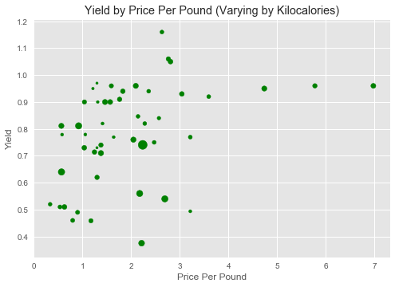

```python
#Making all variables numeric so I can manipulate them
fresh_nutr_df[["price_per_lb", "yield", "kcal", "protien", "fiber", "vitamin C"]] = fresh_nutr_df[["price_per_lb",
                                                        "yield", "kcal", "protien", "fiber", "vitamin C"]].apply(pd.to_numeric)

fresh_nutr_df.loc[:,'kcal']*453.592  #so the units are consistant, I made kcals into kcal per pound instead of per gram

plt.scatter(fresh_nutr_df.iloc[:,1], fresh_nutr_df.iloc[:,2], s = fresh_nutr_df.iloc[:,8]*3, marker = ".", c = "g")
plt.title('Yield by Price Per Pound (Varying by Kilocalories)')
plt.ylabel('Yield')
plt.xlabel('Price Per Pound')

plt.show()
```

The above graph shows the relationshup between yield, price per pound, and kilocalories. The x-axis shows price per pound, the y-axis shows the yield, and the markers vary in size by the number of kilocalories. The graph allows us to see, in general, what kind of foods have the best combinations. The points that would correspond to the best combination of the three variables are those that are towards the top left and have larger circles. I would say that those points below 2 dollars per pound, and above 0.8 yield, with a medium sized circle are the best combination of the three variables. Below, I plotted a barplot to get a better understanding of which foods specifically had the best combination of the three variables.

```python
kcal_per_lb = fresh_nutr_df.loc[:,'kcal']*453.592
#kcal_per_lb/price_per_lb = kcal/price
#because price_per_lb is actually price*yield/lbs this also takes into account the yield into my nutrition factor
kcal_per_price = kcal_per_lb / fresh_nutr_df.iloc[:,1]
```

```python
kcal_per_price = pd.DataFrame({"kcal_per_price":pd.Series(kcal_per_price)}, index = fresh_nutr_df.index)

final_df = pd.concat([fresh_nutr_df, kcal_per_price], axis=1)
final_df.head()
```

|  | form | price_per_lb | yield | lb_per_cup | price_per_cup | food | type | ndb | kcal | protien | fiber | vitamin C | kcal_per_price |
| --- | --- | --- | --- | --- | --- | --- | --- | --- | --- | --- | --- | --- | --- |
| 0 | Fresh1 | 0.333412 | 0.52 | 0.330693 | 0.212033 | watermelon | fruit | 09326 | 30.0 | 0.61 | 0.4 | 8.1 | 40813.643655 |
| 1 | Fresh1 | 0.535874 | 0.51 | 0.374786 | 0.393800 | cantaloupe | fruit | 09181 | 34.0 | 0.84 | 0.9 | 36.7 | 28779.404195 |
| 2 | Fresh1 | 1.377962 | 0.74 | 0.407855 | 0.759471 | tangerines | fruit | 09221 | 43.0 | 0.50 | 0.2 | 31.0 | 14154.568658 |
| 3 | Fresh1 | 2.358808 | 0.94 | 0.319670 | 0.802171 | strawberries | fruit | 09316 | 32.0 | 0.67 | 2.0 | 58.8 | 6153.506783 |
| 4 | Fresh1 | 1.827416 | 0.94 | 0.363763 | 0.707176 | plums | fruit | 09279 | 46.0 | 0.70 | 1.4 | 9.5 | 11417.888379 |

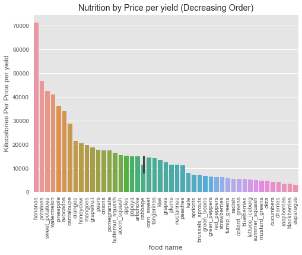

```python
#sorting the df so that it is sorted by kcal_per_price
sorted_food = final_df.sort_values(by = final_df.columns[12], ascending = False)

#create bar plot with food and kcal_per_price
nutr_bar = sns.barplot(x = "food", y = "kcal_per_price", data = sorted_food)
#turns the fruit names on the x-axis so that they are readable
for item in nutr_bar.get_xticklabels():
    item.set_rotation(90)
#renaming the plot and changing the y and x labels for the axes
sns.plt.title('Nutrition by Price per yield (Decreasing Order)')
nutr_bar.set(ylabel = 'Kilocalories Per Price per yield', xlabel = 'food name')
sns.plt.show()
```

To create the above plot, I found the number of kilocalories per price for each of the foods. To do this, I first found the kilocalories per lb and divided by the price per lb to cancel out all terms until I got to kcal per price per yield (the price_per_lb calculation included yield, so I kept it in my calculation so all three terms were present). This graph tells us that, with kilocalories determining our level of nutrition, bananas, potatoes, sweet potatoes, watermelon, and pineapple are the top 5 best foods (fruits and veggies) that combine nutrition, price, and yield. The worst foods that combine nutrition, price, and yield are cucumbers, cherries, raspberries, blackberries, and asparagus. It makes sense that a lot of berries are toward the later side of this graph becaus they cost a lot more than other foods we were comparing against.